## 📊 🔍 Projet Machine learning Modélisation du pauvreté: Les Determinants de la pauvreté ?

# Table of Contents

- Introduction
- Source des données
- Importation des Libraries
- Importation des jeu des données
- Exploration des données
- Selection des Variables
- Netoyage des Données
- Visualisations des Données
- Implémentation du Module
- Matrice de Corrélation et Confusion
- Selection des Features et Target
- Entrainement et Test du modèl
- Evalution du modèl
- Evaluation Uderfitting & Overfitting
- Interface pour le modèl
- Conclusion

# Introduction

La pauvreté est un défi majeur auquel de nombreux pays sont confrontés, et sa compréhension est essentielle pour orienter les politiques publiques et les interventions ciblées. Ce projet vise à développer un modèle de machine learning capable de prédire si un ménage est pauvre ou non en fonction de ses caractéristiques socio-économiques et démographiques.

Grâce à l'analyse de données pertinentes, ce modèle permettra non seulement de mieux comprendre les facteurs associés à la pauvreté, mais aussi de fournir un outil prédictif utile pour les décideurs et les organisations travaillant dans le domaine de la lutte contre la pauvreté. En automatisant cette analyse, le projet contribuera à identifier les ménages les plus vulnérables, facilitant ainsi la mise en œuvre de solutions adaptées et efficaces.

Nous avons décidé d'utiliser la régression logistique pour résoudre notre problématique en raison de la simplicité et de la robustesse de ce modèle. La régression logistique est particulièrement adaptée aux problèmes de classification binaire, comme celui qui consiste à prédire si un ménage est pauvre ou non.

Sa simplicité réside dans sa structure mathématique, qui est facile à comprendre et à interpréter. En effet, ce modèle permet de quantifier l’impact de chaque variable explicative sur la probabilité d’appartenance à une catégorie (pauvre ou non pauvre), grâce à des coefficients clairs et directement exploitables. Cela en fait un choix judicieux lorsque l’objectif est non seulement de prédire, mais aussi d’expliquer les facteurs influençant la pauvreté.

En outre, la régression logistique est reconnue pour sa stabilité, car elle est moins sujette au surapprentissage, notamment lorsque le jeu de données est limité ou bien préparé. Elle s'avère également efficace lorsque les relations entre les variables explicatives et la variable cible sont essentiellement linéaires.

En optant pour ce modèle, nous allions simplicité d’implémentation, facilité d’interprétation et fiabilité des résultats, tout en posant les bases d’un outil prédictif et explicatif robuste pour mieux comprendre et combattre la pauvreté.

# Source des données

L’Enquête Permanente sur les Conditions de Vie des Ménages (EPCVM) 2019, menée par l’Agence Nationale de la Statistique et de l’Analyse Démographique et Économique (ANSADE), constitue une source précieuse pour analyser la pauvreté et les conditions de vie des ménages. Cette enquête vise à fournir des indicateurs détaillés sur les aspects socio-économiques et démographiques des ménages, permettant ainsi de dresser un portrait global des disparités et des vulnérabilités au sein de la population.

### Structure des données

Les données de l’EPCVM 2019 comprennent plusieurs catégories de variables, notamment :

- **Caractéristiques démographiques :** Taille des ménages, composition par âge et sexe, situation matrimoniale.
- **Conditions économiques :** Niveau de revenu, source principale de revenus, emploi et activité économique des membres actifs.
- **Conditions de vie :** Accès aux services de base tels que l’eau potable, l’électricité, et les infrastructures sanitaires.
- **Éducation et santé :** Niveau d’éducation des membres, accès aux soins médicaux, couverture sanitaire.
- **Habitat et logement :** Type de logement, matériaux de construction, nombre de pièces, densité de la population dans le logement.

# Importation des bibliothèques

Cette section contient toutes les bibliothèques nécessaires pour analyser et traiter les données...

```python
import pandas as pd
import numpy as np
import matplotlib.pyplot as plt
import seaborn as sns
```

```python
import warnings

# Ignorer tous les warnings
warnings.filterwarnings('ignore')
```

# Importation du jeu des données

```python
data=pd.read_csv('EPCVM_2019.csv')
data.shape
```

```
(13705, 38)
```

Notre jeu des données contient 13705 observations et 38 variables.

# Analyses Exploratoires des données

Dans cette section vous allons faires des analyses exploratoires sur notre bases base des données on vas proceder par une selection des variables qu'on vas utiliser dans notre étude qui seront introduit dans notre modèl et ensuite faire faire des netoyages des données qui vas inclures gestion des valeurs manquantes detection des valeurs abérantes et finir par une visualisation des données.

## Selection des Variales

```python
# Renomination des valeurs du variable milieu
data['milieu']=data['milieu'].replace(['rural 2000'], "Rural")
data['milieu']=data['milieu'].replace(['urbain 2000'], "Urbain")
```

```python
# selection des variables à etudier
data_model=data[['milieu','wilaya', 'taille', 'typmen', 'sexecm','sitmatcm','nivcm','deptot','aliment','depeduc', 'autdep','depsante', 'logement' ,'transp','pauvre' ]]
```

- **typmen** : Type de ménage
- **sexecm** : Sexe du chef de ménage
- **sitmatcm** : Situation matrimoniale du chef de ménage
- **nivcm** : Niveau d’éducation du chef de ménage
- **deptot** : Dépenses totales du ménage
- **aliment** : Dépenses alimentaires du ménage
- **depeduc** : Dépenses en éducation du ménage
- **autdep** : Autres dépenses du ménage
- **depsante** : Dépenses en santé du ménage
- **logement** : Dépenses liées au logement du ménage
- **transp** : Dépenses en transport du ménage
- **pauvre** : Indicateur de pauvreté du ménage (cible de prédiction)

## Netoyages des données

Nous allons procéder à un nettoyage approfondi de notre base de données en identifiant et en traitant les valeurs manquantes, ainsi que les valeurs aberrantes. Cette étape est cruciale pour améliorer la qualité et la fiabilité des données, afin d'assurer des analyses plus précises et des résultats plus fiables. Nous allons utiliser diverses techniques pour combler les valeurs manquantes, comme l'imputation, et pour détecter et traiter les valeurs aberrantes, telles que les outliers. L'objectif est de rendre notre base de données propre et cohérente, ce qui facilitera les étapes suivantes de notre projet d'analyse ou de modélisation.

### Traitement des Valeurs manquantes

```python
data_missing_value=data_model.isnull().sum()
data_missing_value=data_missing_value/len(data_model)*100

missdata=data_missing_value.drop(data_missing_value[data_missing_value==0].index).sort_values(ascending=False).reset_index(name=('% missing_value'))
missdata
```

|  | index | % missing_value |
| --- | --- | --- |
| 0 | depsante | 62.327618 |
| 1 | transp | 60.160525 |
| 2 | depeduc | 43.867202 |
| 3 | logement | 3.889092 |
| 4 | autdep | 1.094491 |
| 5 | aliment | 0.569135 |
| 6 | sitmatcm | 0.248085 |
| 7 | deptot | 0.072966 |

On observe que nous avons des variables qui ont des valeurs manquantes surtout les variables depense en santé, dépense en transport et les dépense en éducation qui ont plus de 40% des valeurs manquantes.

On vas utiliser la méthode imputation pour remplacer les valeurs manquante

- Pour la **Variable qualitative** nous allons remplacer les valeurs manquantes par le mode
- Pour les **Variables Quantitatives** nous remplacer les valeurs manquantes aléatoirement mais en se basant sur une intervalle qui utlise la loi uniform

```python
# Remplacer les valeurs manquantes de la colonne 'sitmatcm' par la valeur la plus fréquente (mode)
mode_value = data_model['sitmatcm'].mode()[0]  # Prendre la première valeur du mode
data_model['sitmatcm'].fillna(mode_value, inplace=True)

# Remplacons les valeurs manquantes des variables quantitatives aléatoirement
import numpy as np

# Liste des variables pour lesquelles je vais remplacer les valeurs manquantes
variables = ['depsante', 'transp', 'depeduc', 'logement', 'autdep', 'aliment', 'deptot']

# Parcourir chaque variable pour traiter les valeurs manquantes
for var in variables:
    # Calcul de la moyenne et de l'écart-type de la variable
    mean_value = data_model[var].mean()
    std_value = data_model[var].std()

    # Calcul du nombre de valeurs manquantes (NaN) dans la variable
    na_count = data_model[var].isnull().sum()  # `sum()` donne le nombre de NaN

    # Générer des valeurs aléatoires dans l'intervalle [moyenne - écart-type, moyenne + écart-type]
    random_values = np.random.uniform(mean_value - std_value, mean_value + std_value, na_count)

    # Remplacer les valeurs manquantes par les valeurs générées
    data_model.loc[data_model[var].isnull(), var] = random_values
```

```python
# Calculer le nombre total de valeurs manquantes dans toutes les colonnes
total_missing = data_model.isnull().sum().sum()

# Calculer le nombre total de valeurs dans la base de données
total_values = data_model.size

# Calculer le pourcentage de valeurs manquantes
missing_percentage = (total_missing / total_values) * 100

# Afficher le pourcentage de valeurs manquantes
print(f"Pourcentage des valeurs manquantes dans la base de données : {missing_percentage:.2f}%")
```

```
Pourcentage des valeurs manquantes dans la base de données : 0.00%
```

Suite au processus de nettoyage des données, nous avons pu identifier et traiter toutes les valeurs manquantes dans notre base de données. Grâce à ce nettoyage, nous pouvons affirmer que notre base de données est désormais complète et ne contient plus de valeurs manquantes, ce qui garantit la qualité et la fiabilité des analyses futures.

```python
# Recodage des modalités du variables type de ménage
data_model['typmen']=data_model['typmen'].replace(['mÃ©nage de famille Ã©largi', 'MÃ©nage unipersonnel', 'couple sans enfants'], 'Autres')
data_model['typmen']=data_model['typmen'].replace(['MÃ©nage monoparental nuclÃ©aire', 'MÃ©nage monoparental Ã©largi'], 'Ménage monoparental')

# Renomons les modalité du variable sitmatcm
data_model['sitmatcm']=data_model['sitmatcm'].replace(['divorcÃ©(e)'], 'divorcé(e)')
data_model['sitmatcm']=data_model['sitmatcm'].replace(['jamais mariÃ©'], 'jamais marié')

# Recodage des modalités du variable 'nivcm' le niveau du chef de ménage
data_model['nivcm']=data_model['nivcm'].replace(['Pas de niveau', 'AlphabÃ©tisation', 'ND'], 'Pas de Niveau')
data_model['nivcm']=data_model['nivcm'].replace(['Traditionnel','PrÃ©scolaire'], 'Mahdara')
data_model['nivcm']=data_model['nivcm'].replace(['Secondaire tech./prof.', 'Secondaire gÃ©nÃ©ral'], 'Sécondaire')
data_model['nivcm']=data_model['nivcm'].replace(['SupÃ©rieur'], 'Supérieur')
```

### Traitement des Valeurs Aberrantes

```python
round(data_model.describe(), 2)
```

|  | taille | deptot | aliment | depeduc | autdep | depsante | logement | transp |
| --- | --- | --- | --- | --- | --- | --- | --- | --- |
| count | 13705.00 | 13705.00 | 13705.00 | 13705.00 | 13705.00 | 13705.00 | 13705.00 | 13705.00 |
| mean | 5.47 | 1044662.84 | 607218.59 | 17049.60 | 86691.10 | 109099.40 | 155853.08 | 64738.93 |
| std | 2.80 | 735952.61 | 333749.76 | 28625.87 | 75449.07 | 131207.46 | 250652.78 | 73035.50 |
| min | 1.00 | 3360.00 | 800.00 | -16915.54 | 120.00 | -63061.98 | -97973.60 | -28931.87 |
| 25% | 3.00 | 571320.00 | 363980.00 | 3000.00 | 34040.00 | 25220.08 | 34820.98 | 15001.00 |
| 50% | 5.00 | 875360.00 | 554360.00 | 9523.89 | 66760.00 | 87644.01 | 83000.00 | 48132.03 |
| 75% | 7.00 | 1312510.00 | 793377.00 | 25000.00 | 116551.58 | 179496.90 | 186000.00 | 100519.44 |
| max | 36.00 | 11974960.00 | 4099540.00 | 568000.00 | 802740.00 | 6000000.00 | 5790000.00 | 1176000.00 |

D'après l'analyse descriptive de la base de données, nous constatons que les valeurs minimales des variables liées aux dépenses en éducation, santé, logement et transport sont négatives. Ce résultat est surprenant, car il est illogique d'avoir des montants négatifs dans ces domaines, ce qui suggère qu'il s'agit probablement de valeurs aberrantes. Une situation similaire est observée pour la variable représentant la taille des ménages, dont la valeur maximale semble également être une anomalie, car elle est bien au-delà des valeurs attendues. Ces valeurs extrêmes doivent être examinées de plus près, car elles pourraient fausser les analyses et les prédictions basées sur ces données. Il serait donc nécessaire de nettoyer et de traiter ces valeurs aberrantes afin d'améliorer la qualité des données utilisées pour les analyses ultérieures.

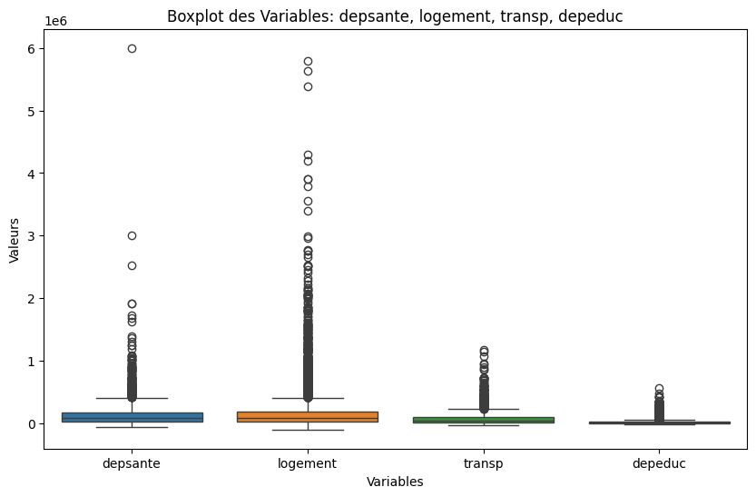

```python
import matplotlib.pyplot as plt
import seaborn as sns

# Liste des variables
variables = ['depsante', 'logement', 'transp', 'depeduc']

# Créer le boxplot
plt.figure(figsize=(10, 6))  # Taille de la figure

# Utiliser seaborn pour créer le boxplot
sns.boxplot(data=data_model[variables])

# Ajouter des labels et un titre
plt.title('Boxplot des Variables: depsante, logement, transp, depeduc')
plt.xlabel('Variables')
plt.ylabel('Valeurs')

# Afficher le graphique
plt.show()
```

```python
# Compter les lignes où la variable 'depeduc' est négative
negative_depeduc_count = (data_model[data_model['depsante'] < 0].shape[0]/data_model.shape[0])*100

# Afficher le nombre de lignes
print(f"Nombre de lignes où 'depeduc' est négatif : {negative_depeduc_count}")
```

```
Nombre de lignes où 'depeduc' est négatif : 11.57241882524626
```

```python
# Remplacer les valeurs négatives de par leurs valeurs absolues
data_model['depsante'] = data_model['depsante'].apply(lambda x: abs(x) if x < 0 else x)
data_model['logement'] = data_model['logement'].apply(lambda x: abs(x) if x < 0 else x)
data_model['transp'] = data_model['transp'].apply(lambda x: abs(x) if x < 0 else x)
data_model['depeduc'] = data_model['depeduc'].apply(lambda x: abs(x) if x < 0 else x)
```

[figure not shown]

```python
import matplotlib.pyplot as plt
import seaborn as sns


# Créer le boxplot
plt.figure(figsize=(10, 6))  # Taille de la figure

# Utiliser seaborn pour créer le boxplot
sns.boxplot(data=data_model['taille'])

# Ajouter des labels et un titre
plt.title('Boxplot des Variables: depsante, logement, transp, depeduc')
plt.xlabel('Variables')
plt.ylabel('Valeurs')

# Afficher le graphique
plt.show()
```

### Visualisations des Données

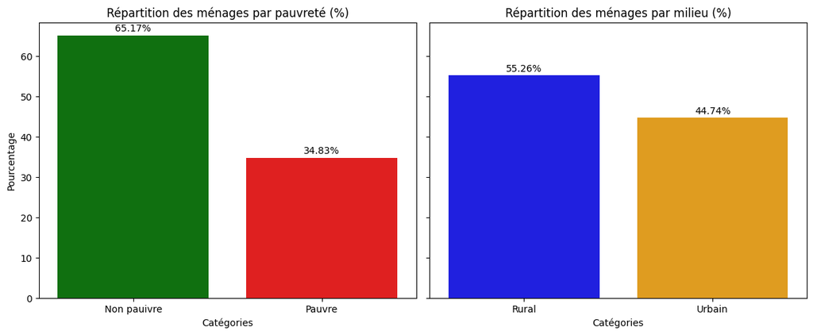

```python
import matplotlib.pyplot as plt
import seaborn as sns

# ---- Données pour "pauvre" ----
data_pauvre = data_model['pauvre'].value_counts()
categories_pauvre = data_pauvre.index.tolist()
values_pauvre = data_pauvre.values.tolist()

# Calcul des pourcentages pour "pauvre"
total_pauvre = sum(values_pauvre)
percentages_pauvre = [(value / total_pauvre) * 100 for value in values_pauvre]

# ---- Données pour "milieu" ----
data_milieu = data_model['milieu'].value_counts()
categories_milieu = data_milieu.index.tolist()
values_milieu = data_milieu.values.tolist()

# Calcul des pourcentages pour "milieu"
total_milieu = sum(values_milieu)
percentages_milieu = [(value / total_milieu) * 100 for value in values_milieu]

# ---- Configuration des sous-graphiques ----
fig, axes = plt.subplots(1, 2, figsize=(12, 5), sharey=True)  # Une ligne, deux colonnes

# ---- Graphique pour "pauvre" ----
sns.barplot(
    x=categories_pauvre,
    y=percentages_pauvre,
    palette=["green", "red"],
    ax=axes[0]
)
axes[0].set_title("Répartition des ménages par pauvreté (%)")
axes[0].set_xlabel("Catégories")
axes[0].set_ylabel("Pourcentage")
for index, value in enumerate(percentages_pauvre):
    axes[0].text(index, value + 1, f"{value:.2f}%", ha='center', fontsize=10)

# ---- Graphique pour "milieu" ----
sns.barplot(
    x=categories_milieu,
    y=percentages_milieu,
    palette=["blue", "orange"],
    ax=axes[1]
)
axes[1].set_title("Répartition des ménages par milieu (%)")
axes[1].set_xlabel("Catégories")
axes[1].set_ylabel("")  # Pas besoin de répéter l'étiquette des pourcentages
for index, value in enumerate(percentages_milieu):
    axes[1].text(index, value + 1, f"{value:.2f}%", ha='center', fontsize=10)

# ---- Affichage ----
plt.tight_layout()
plt.show()
```

D'après l'analyse Nous Contatons que parmi les ménage étudie 65.17% son pas pauvre tandit que 34.83% des ménage sont pauvre ce qui veut dire que 34.83% des ménages consomme moins que 1.90$ par jour. Et nous constatons que parmi ses ménages 55.26% sont dans les milieu Rural et 44.74% sont dans le milieu Urbain.

# Implémentation du Modèle

```python
df_quali=data_model.select_dtypes(include=['float64', 'float32'])
```

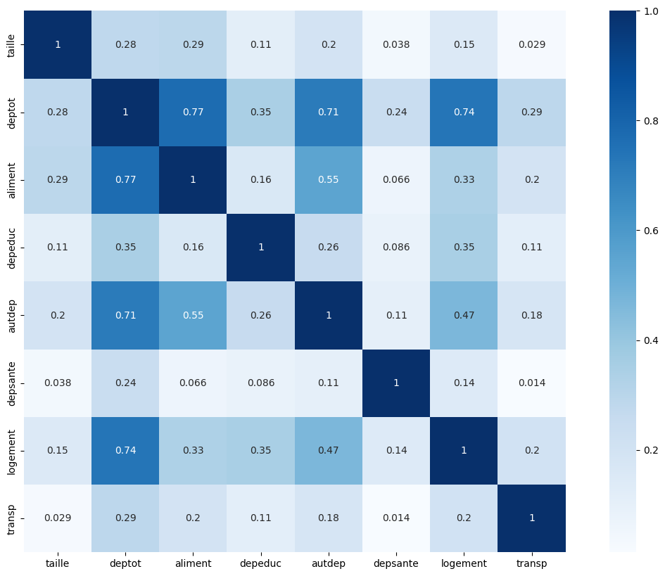

```python
plt.figure(figsize=(16,10))
sns.heatmap(df_quali.corr(),
           cmap='Blues',
           annot=True,
           square=True)
plt.show()
```

```python
df_quanti=data_model.select_dtypes(exclude=['float64', 'float32'])
```

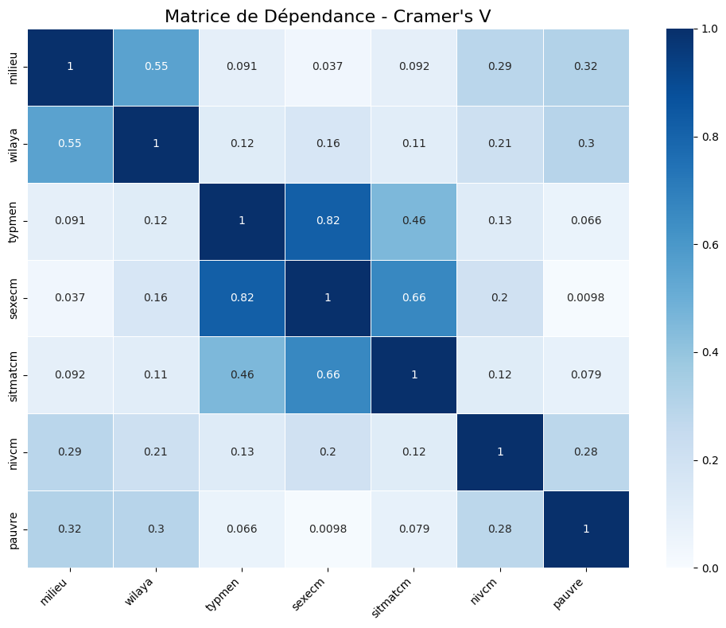

```python
import pandas as pd
import numpy as np
import seaborn as sns
import matplotlib.pyplot as plt
from scipy.stats import chi2_contingency

# Fonction pour calculer le Cramer's V
def cramers_v(confusion_matrix):
    chi2, p, dof, expected = chi2_contingency(confusion_matrix)
    n = confusion_matrix.sum().sum()
    r, k = confusion_matrix.shape
    return np.sqrt(chi2 / (n * (min(k - 1, r - 1))))

# Fonction pour créer une matrice de Cramer's V pour les colonnes spécifiées
def cramer_v_matrix(df_quanti, cols):
    n = len(cols)
    matrix = np.zeros((n, n))

    for i in range(n):
        for j in range(i, n):
            if i == j:
                matrix[i, j] = 1.0
            else:
                contingency_table = pd.crosstab(df_quanti[cols[i]], df_quanti[cols[j]])
                matrix[i, j] = cramers_v(contingency_table)
                matrix[j, i] = matrix[i, j]

    return pd.DataFrame(matrix, index=cols, columns=cols)

# Liste des colonnes à analyser
cols = df_quanti.columns

# Calcul de la matrice de Cramer's V
cramers_v_df = cramer_v_matrix(df_quanti, cols)

# Visualisation de la matrice de Cramer's V avec une heatmap
plt.figure(figsize=(10, 8))
sns.heatmap(cramers_v_df, annot=True, cmap='Blues', linewidths=0.5, vmin=0, vmax=1)
plt.title("Matrice de Dépendance - Cramer's V", fontsize=16)
plt.xticks(rotation=45, ha='right', fontsize=10)
plt.yticks(fontsize=10)

plt.tight_layout()
plt.show()
```

## Selection des Features et target

```python
features=['wilaya', 'taille', 'typmen', 'sitmatcm', 'nivcm',
        'aliment', 'depeduc', 'autdep', 'depsante', 'logement',
       'transp']

target=['pauvre']
```

```python
from sklearn.preprocessing import StandardScaler

X=data_model[features]
Y=data_model[target]
# Encodage des variables catégoriques
X = pd.get_dummies(X, drop_first=True)

# Normalisation des variables numériques
scaler = StandardScaler()
X = scaler.fit_transform(X)
```

## Entrainement et Test du modèl

```python
from sklearn.tree import DecisionTreeClassifier, plot_tree
from sklearn.model_selection import train_test_split
from sklearn.linear_model import LogisticRegression


# Instancie le modèle de régression logistique
model = LogisticRegression(max_iter=1000)

# Split the data into training and testing sets
X_train, X_test, Y_train, Y_test = train_test_split(X, Y, test_size=0.3, random_state=42)

# Train the model
model.fit(X_train, Y_train)
```

```
LogisticRegression(max_iter=1000)
```

## Evaluation du Modèl

```python
from sklearn.metrics import accuracy_score

# Prédictions sur l'ensemble de test
y_pred = model.predict(X_test)
# Prédictions sur l'ensemble d'entraînement pour le f1-score
y_train_pred = model.predict(X_train)
# Évalue le modèle
accuracy = accuracy_score(Y_test, y_pred)
print("Accuracy:", accuracy)
```

```
Accuracy: 0.9375
```

La performance de notre modèle atteint un taux de 94%, ce qui indique que celui-ci est capable de fournir des prédictions correctes dans 94% des cas lorsqu'il est testé sur des données qu'il n'a jamais vues auparavant. Cette mesure, reflète la proportion de prédictions justes par rapport à l'ensemble des données testées.

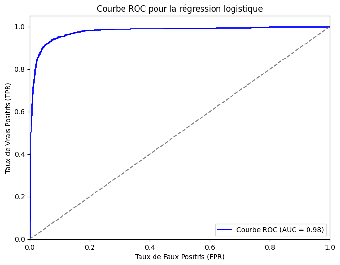

```python
import matplotlib.pyplot as plt
from sklearn.metrics import roc_curve, auc
from sklearn.linear_model import LogisticRegression
from sklearn.model_selection import train_test_split
from sklearn.preprocessing import LabelEncoder, StandardScaler
import pandas as pd


# Encodage des labels ('Non pauvre' -> 0, 'Pauvre' -> 1)
encoder = LabelEncoder()
y_encoded = encoder.fit_transform(Y)

# Séparation en jeu d'entraînement et jeu de test
x_train,x_test, y_train, y_test = train_test_split(X, y_encoded, test_size=0.3, random_state=42)

# Entraînement du modèle de régression logistique
model = LogisticRegression()
model.fit(x_train, y_train)

# Prédictions des probabilités sur le jeu de test
y_probs = model.predict_proba(x_test)[:, 1]  # Probabilités pour la classe positive (Pauvre)

# Calcul du FPR et du TPR
fpr, tpr, thresholds = roc_curve(y_test, y_probs)

# Calcul de l'AUC (Area Under the Curve)
roc_auc = auc(fpr, tpr)

# Tracé de la courbe ROC
plt.figure(figsize=(8, 6))
plt.plot(fpr, tpr, color='blue', lw=2, label=f'Courbe ROC (AUC = {roc_auc:.2f})')
plt.plot([0, 1], [0, 1], color='gray', linestyle='--')  # Ligne diagonale
plt.xlim([0.0, 1.0])
plt.ylim([0.0, 1.05])
plt.xlabel('Taux de Faux Positifs (FPR)')
plt.ylabel('Taux de Vrais Positifs (TPR)')
plt.title('Courbe ROC pour la régression logistique')
plt.legend(loc='lower right')
plt.show()
```

Un AUC-ROC (Area Under the Curve - Receiver Operating Characteristic) de 0,98 est un excellent indicateur de performance pour un modèle de classification. Cette valeur reflète la capacité du modèle à distinguer efficacement entre les deux classes cibles, comme "pauvre" et "non pauvre".

## Evaluation de Underfitting & Overfiting

```python
from sklearn.linear_model import LogisticRegression
from sklearn.metrics import accuracy_score

# Modèle Ridge (pénalité L2)
ridge_model = LogisticRegression(penalty='l2', max_iter=1000, solver='liblinear')  # solver 'liblinear' prend en charge L1 et L2
# Entraîne le modèle
ridge_model.fit(X_train, Y_train)
# Prédictions sur l'ensemble de test
ridge_y_pred = ridge_model.predict(X_test)
# Évalue le modèle
ridge_accuracy = accuracy_score(Y_test, ridge_y_pred)
print("Ridge Logistic Regression - Accuracy:", ridge_accuracy)


# Modèle Lasso (pénalité L1)
lasso_model = LogisticRegression(penalty='l1', max_iter=1000, solver='liblinear')  # 'liblinear' est requis pour L1
# Entraîne le modèle
lasso_model.fit(X_train, Y_train)
# Prédictions sur l'ensemble de test
lasso_y_pred = lasso_model.predict(X_test)
# Évalue le modèle
lasso_accuracy = accuracy_score(Y_test, lasso_y_pred)
print("Lasso Logistic Regression - Accuracy:", lasso_accuracy)
```

```
Ridge Logistic Regression - Accuracy: 0.9377431906614786
Lasso Logistic Regression - Accuracy: 0.9382295719844358
```

Les valeurs d'accuracy obtenues par les modèles de régularisation sont très proches de celles de notre modèle initial. Cela indique que notre modèle présente un bon équilibre entre biais et variance, ce qui signifie qu'il ne souffre ni de sous-apprentissage (underfitting), ni de sur-apprentissage (overfitting).

# Interface pour le modèl

```python
data=data_model
```

```python
import gradio as gr
import pandas as pd
from sklearn.preprocessing import StandardScaler, LabelEncoder
from sklearn.linear_model import LogisticRegression
from sklearn.model_selection import train_test_split



# Détection des colonnes catégoriques et numériques
categorical_columns = list(data_model.select_dtypes(include=['object', 'category']).columns)
numerical_columns = list(data_model.select_dtypes(include=['int64', 'float64']).columns)

# Préparation des données
X = data_model[categorical_columns + numerical_columns]
y = data_model["pauvre"]

# Encodage des colonnes catégoriques
X = pd.get_dummies(X, drop_first=True)

# Normalisation
scaler = StandardScaler()
X_scaled = scaler.fit_transform(X)

# Encoder la variable cible (si nécessaire)
encoder = LabelEncoder()
y = encoder.fit_transform(y)

# Entraîner le modèle
model = LogisticRegression(max_iter=1000)
X_train, X_test, y_train, y_test = train_test_split(X_scaled, y, test_size=0.2, random_state=42)
model.fit(X_train, y_train)

# Fonction pour prédire la pauvreté
def predict_poverty(wilaya, taille, typmen, sitmatcm, nivcm, aliment, depeduc, autdep, depsante, logement, transp):
    try:
        # Convertir les entrées utilisateur en un DataFrame
        input_data = pd.DataFrame({
            "wilaya": [wilaya],
            "taille": [taille],
            "typmen": [typmen],
            "sitmatcm": [sitmatcm],
            "nivcm": [nivcm],
            "aliment": [aliment],
            "depeduc": [depeduc],
            "autdep": [autdep],
            "depsante": [depsante],
            "logement": [logement],
            "transp": [transp],
        })

        # Encodage des variables catégoriques
        input_data = pd.get_dummies(input_data)
        for col in X.columns:
            if col not in input_data.columns:
                input_data[col] = 0  # Ajouter les colonnes manquantes

        # Réorganiser les colonnes
        input_data = input_data[X.columns]

        # Normalisation
        input_data_scaled = scaler.transform(input_data)

        # Prédiction
        prediction = model.predict(input_data_scaled)
        prob = model.predict_proba(input_data_scaled)[0][1]

        return "Pauvre" if prediction[0] == 1 else "Non Pauvre", f"Probabilité : {prob:.2f}"
    except Exception as e:
        return "Erreur", str(e)

# Interface Gradio
inputs = [
    gr.Textbox(label="Wilaya"),
    gr.Number(label="Taille"),
    gr.Textbox(label="Type de ménage"),
    gr.Textbox(label="Situation matrimoniale"),
    gr.Textbox(label="Niveau d'étude du chef de ménage"),
    gr.Number(label="Dépenses alimentaires"),
    gr.Number(label="Dépenses d'éducation"),
    gr.Number(label="Autres dépenses"),
    gr.Number(label="Dépenses de santé"),
    gr.Number(label="Logement"),
    gr.Number(label="Transport"),
]

outputs = [
    gr.Textbox(label="Prédiction"),
    gr.Textbox(label="Probabilité"),
]

interface = gr.Interface(
    fn=predict_poverty,
    inputs=inputs,
    outputs=outputs,
    title="Prédiction de la Pauvreté",
    description="Entrez les informations pour prédire si un ménage est pauvre ou non."
)

interface.launch()
```

```
Running on local URL:  http://127.0.0.1:7860

To create a public link, set `share=True` in `launch()`.
```

[interactive chart not shown]

# Conclusion

En conclusion, nous avons développé un modèle particulièrement robuste, affichant une précision de 94 % et une aire sous la courbe ROC (AUC) de 0,98. Ces performances remarquables démontrent la capacité du modèle à prédire avec fiabilité la pauvreté en Mauritanie.

Grâce à l'intégration de caractéristiques socio-économiques et de facteurs démographiques, ce modèle offre non seulement un outil prédictif efficace, mais aussi une meilleure compréhension des dynamiques qui influencent la pauvreté. Cela en fait un atout précieux pour les décideurs et les organisations œuvrant à la réduction des inégalités et à l'amélioration des conditions de vie des populations vulnérables.